# Sampling: Sampling Plan

Xianbin Cheng

September 7, 2018

# Method

1. Load libraries and source R code from `Sampling_contamination.R`.

```r
source(file = "Sampling_libraries.R")
source(file = "Sampling_contamination.R")
source(file = "Sampling_visualization.R")
```

2. List important parameters from `Sampling_contamination.R`.
- `n_sim` = the number of simulations
- `x_lim` = the limits of the horizontal axis
- `y_lim` = the limits of the vertical axis
- `x` = the horizontal coordinate of the contamination center, which follows a uniform distribution (`U(0,10)`)
- `y` = the vertical coordinate of the contamination center, which follows a uniform distribution(`U(0,10)`)

** Mode 1: Discrete Spread**

- `n_affected` = the number of affected plants near the contamination spot, which follows a Poisson distribution (`Pois(lambda = 5)`)
- `covar_mat` = covariance matrix of `x` and `y`, which defines the spread of contamination. Assume the spread follows a 2D normal distribution with var(X) = 0.25, var(Y) = 0.25 and cov(X, Y) = 0

** Mode 2: Continuous Spread**

- `spread_radius` = the radius of the contamination spread

```r
## The input parameters
n_sim = 3
x_lim = c(0, 10)
y_lim = c(0, 10)

### Mode 1
n_affected = rpois(n = 1, lambda = 5)
covar_mat = matrix(data = c(0.25, 0, 0, 0.25), nrow = 2, ncol = 2)

### Mode 2
spread_radius = 2.5
```

```r
# Generate the coordinates of contamination points
contam_xy = sim_contam(n_sim = n_sim, x_lim = x_lim, y_lim = y_lim, covariance = covar_mat, n_affected = n_affected, radius = spread_radius)
```

```r
## Basic info of the contamination simulation
str(contam_xy)
```

```
## 'data.frame':    17 obs. of  5 variables:
##  $ X    : num  9.73 8.38 7.83 9.18 9.08 ...
##  $ Y    : num  1.9895 0.0472 2.0906 1.089 2.9449 ...
##  $ ID   : Factor w/ 18 levels "1-0","2-0","3-0",..: 1 2 3 4 5 6 8 9 10 11 ...
##  $ label: Factor w/ 2 levels "spot","spread": 1 1 1 2 2 2 2 2 2 2 ...
##  $ r    : num  2.5 2.5 2.5 2.5 2.5 2.5 2.5 2.5 2.5 2.5 ...
```

```r
summary(contam_xy$label)
```

```
##   spot spread
##      3     14
```

3. Define parameters for generating sampling plans.
- `n_sp` = the number of sampling points
- `sp_radius` = the radius (m) of a circular region around the sample point. (Only applicable to **Mode 1: Discrete Spread**)

```r
n_sp = 10
sp_radius = 1
```

4. Simulate a sampling plan. In this case, we simulate a simple random sampling plan. The coordinates of sampling points follows a uniform distribution $U(0,10)$.

```r
# Run this if we want reproducibility
#set.seed(123)
```

```r
# Create a function that generates a simple random sampling plan
sim_plan = function(n_sp, x_lim, y_lim, radius){

  ## Generate a data frame that contains the coordinates of the sampling points
  x_sp = runif(n = n_sp, min = x_lim[1], max = x_lim[2])
  y_sp = runif(n = n_sp, min = y_lim[1], max = y_lim[2])

  ## Generate a unique identifier for each sample point
  a = rep("sp", times = n_sp)
  b = 1:n_sp %>% as.character()
  ID = paste(a, "-", b, sep = "")

  ## Generate a column for sample radius
  r = rep(radius, times = n_sp)

  data.frame(X = x_sp,
             Y = y_sp,
             ID = ID,
             label = "sample point",
             r = r)
}
```

```r
sp_xy = sim_plan(n_sp = n_sp, x_lim = x_lim, y_lim = y_lim, r = sp_radius)
```

5. Combine the `sp_xy` and `contam_xy` by row.

```r
contam_sp_xy = rbind(contam_xy, sp_xy)
rownames(contam_sp_xy) = NULL
```

# Results

1. Show the simulated contamination.

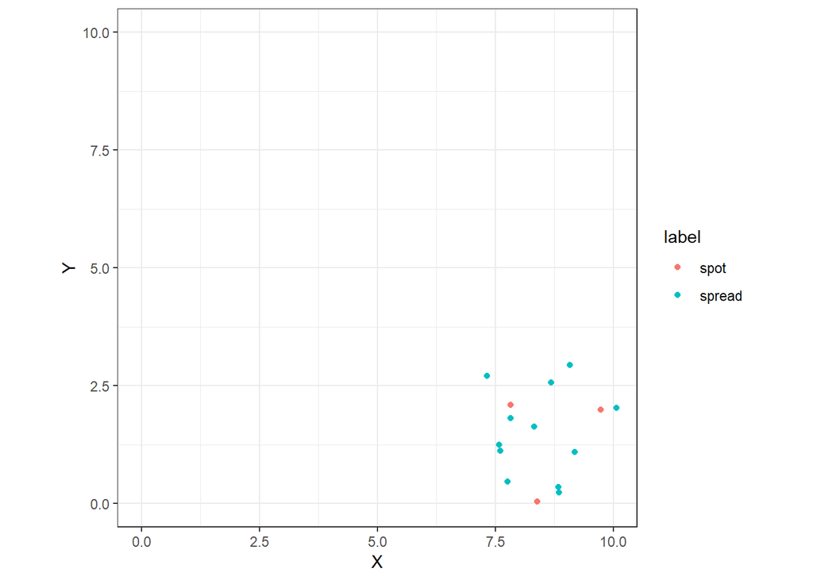

```r
# Mode 1: Discrete Spread
plot_contam_dis = contam_draw(data = contam_xy, method = "discrete", xlim = x_lim, ylim = y_lim)

plot_contam_dis
```

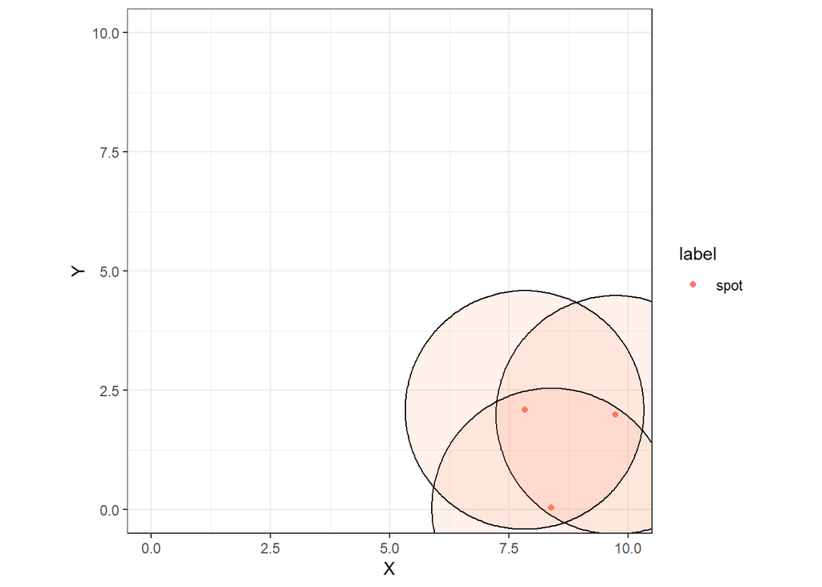

```r
# Mode 2: Continuous Spread
plot_contam_cont = contam_draw(data = contam_xy, method = "continuous", xlim = x_lim, ylim = y_lim)

plot_contam_cont
```

2. Show the sample points and sample regions.

```r
plot_sp_dis = sp_draw(data = sp_xy, method = "discrete", xlim = x_lim, ylim = y_lim)

plot_sp_cont = sp_draw(data = sp_xy, method = "continuous", xlim = x_lim, ylim = y_lim)
```

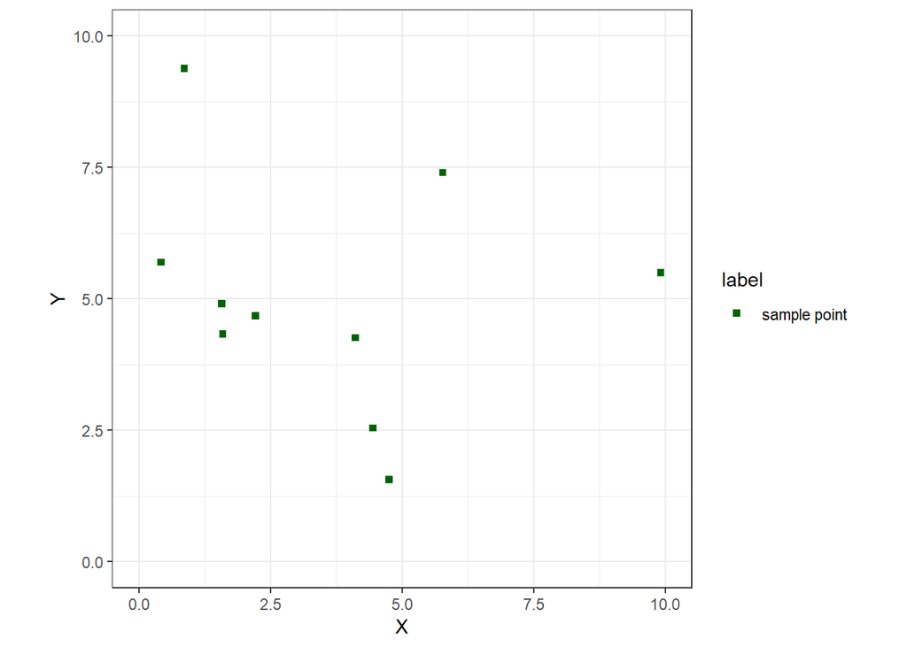

```r
# Sampling plan for continuous spread
plot_sp_cont
```

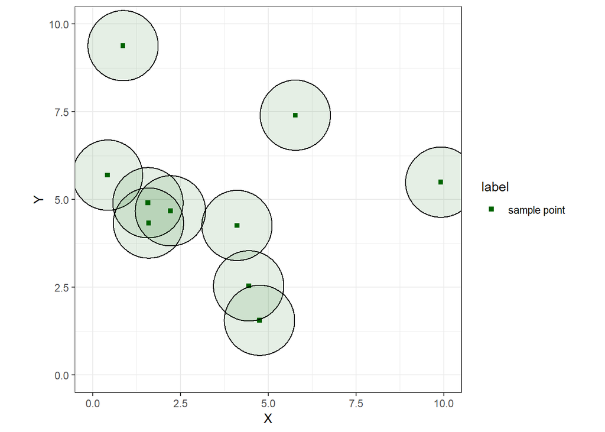

```r
# Sampling plan for discrete spread
plot_sp_dis
```

3. Overlay the sampling plan on the simulated contamination plot.

```r
plot_overlay_cont = overlay_draw(data = contam_sp_xy, method = "continuous", xlim = x_lim, ylim = y_lim)

plot_overlay_dis = overlay_draw(data = contam_sp_xy, method = "discrete", xlim = x_lim, ylim = y_lim)
```

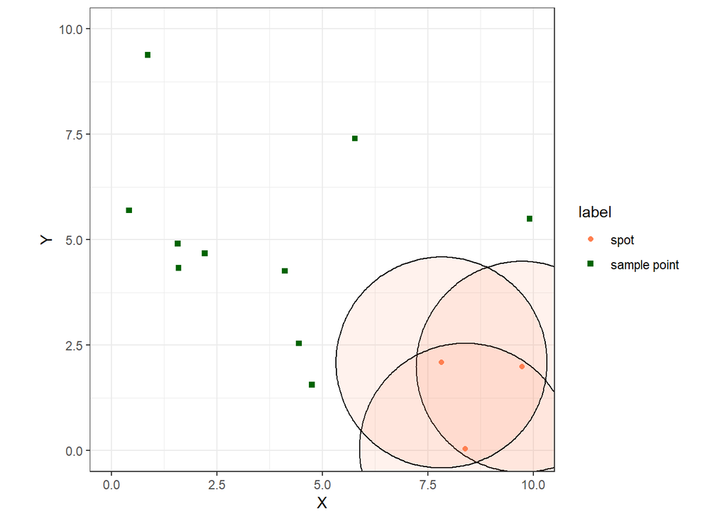

```r
# Sampling plan for continuous spread
plot_overlay_cont
```

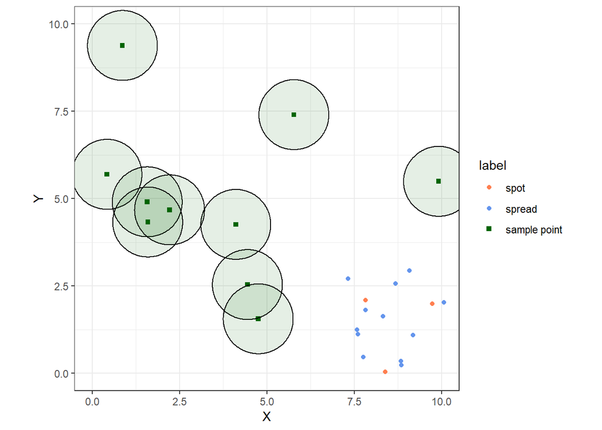

```r
# Sampling plan for discrete spread
plot_overlay_dis
```